# An introduction to tidyverse

### 4.0.1 Exercise: Plotting the EMBL logo

The code below plots the embl logo. The plus sign adds additional “layers” to the ggplot object modifying any given plot and we use it here to make the axes dissapear.

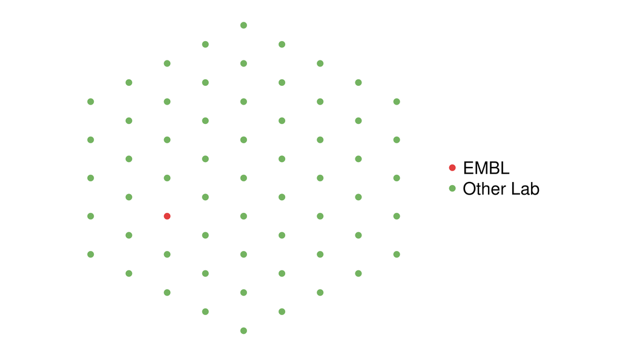

```r
load("hex_grid.Rdata")
embl_colors <- c("#E33E3E", "#73B360")
qplot(x, y, data = hex_grid, color = lab, asp = 1) +
    theme(panel.border = element_blank(),
          panel.grid.major = element_blank(),
          panel.grid.minor = element_blank(),
          axis.text = element_blank(),
          line = element_blank(),
          title = element_blank())+
    scale_color_manual(values=embl_colors)
```

# 5 Programming statements

R offers the typical options for flow–control known from many other languages.

The most important one, the **if–statement** is used when certain computations should only be performed if a certain condition is met (and maybe something else should be performed when the condition is not met):

```r
w <- 3
  if (w < 5) {
      d <- 2
    } else {
      d <- 10
    }
d
```

```
   [1] 2
```

If you want perfom a computation for every entry of a list, you usually do the computations for one time step and then for the next and the next, etc. Because nobody wants to type the same commands over and over again, these computations are automated in **for–loops**.

```r
h <- seq(from = 1, to = 8)
s <- numeric() # create empty  vector
    for (i in 1:8)
    {
    s[i] <- h[i] * 10
    }
s
```

```
   [1] 10 20 30 40 50 60 70 80
```

Note however, that you should typically resort to `map` function for this purpose as this leads to more readable code:

```r
map_dbl(h, ~.x*10)
```

```
   [1] 10 20 30 40 50 60 70 80
```

Another useful command is the **ifelse**–command, it replaces elements of a vector based on the evaluation of another logical vector of the same size. This is useful to replace missing values, or to binarize a vector.

```r
s <- seq(from = 1, to = 10)
binary_s <- ifelse(s > 5, "high", "low")
binary_s
```

```
    [1] "low"  "low"  "low"  "low"  "low"  "high" "high" "high" "high" "high"
```

## 5.1 Exercise: Base calling errors

The function `readError(noBases)` simulates the base calling errors of a sequencing machine. The parameter represents the number of positions in the genome sequenced and the function will return a vector, which has the entry “error” if a base calling error occurs at a certain position and “correct” if the base is read correctly. It can be obtained with the command

`source("readError.R")`

- Let the sequencer read a thousand positions and try to infer a base calling error rate from this simulation HINT: The functions `table` and `prop.table` could be handy for this!
- Let us assume the technology improves and the machine is less prone to errors. Change the function accordingly!

# 6 Answers to exercises

**Exercise: Handling a small data set**

- Import the data set `Patients.csv` from local directory
- Which variables are stored in the data frame and what are their values?
- Is there a missing weight value? If yes, replace it by the mean of the other weight values.
- Calculate the mean weight and height of all the patients.
- Calculate the `BMI = Weight / Height^2` of all the patients.

**Solution: Handling a small data set**

```r
pat <- read_csv("Patients.csv")
pat

map_dbl(keep(pat, is_double), mean)

pat$Weight[2] <- mean(pat$Weight, na.rm = TRUE)
pat

pat <- mutate(pat, BMI = Weight / Height^2)
```

**Exercise: Plotting the EMBL logo**

The code below plots the embl logo. Note that the plus sign adds additional layers to the ggplot object. This allows you to modify any given plot. However the colors are not quite right. Can you fix that? Check out the [ggplot2 docs](http://docs.ggplot2.org/) or try googeling!

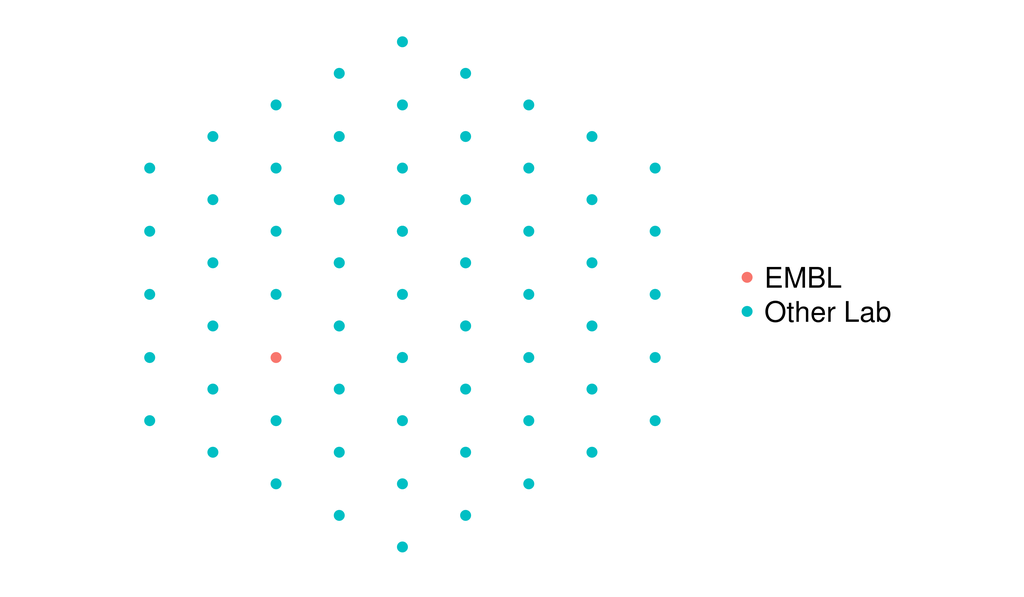

```r
load("hex_grid.Rdata")
embl_colors <- c("#E2001A", "#6FAA46")
qplot(x, y, data = hex_grid, color = lab, asp = 1) +
    theme(panel.border = element_blank(),
          panel.grid.major = element_blank(),
          panel.grid.minor = element_blank(),
          axis.text = element_blank(),
          line = element_blank(),
          title = element_blank())
```

**Solution: Plotting the EMBL logo**

```r
load("hex_grid.Rdata")
embl_colors <- c("#E2001A", "#6FAA46")

qplot(x, y, data = hex_grid, color = lab, asp = 1) +
    theme(panel.border = element_blank(),
          panel.grid.major = element_blank(),
          panel.grid.minor = element_blank(),
          axis.text = element_blank(),
          line = element_blank(),
          title = element_blank()) +
    scale_colour_manual(values = embl_colors )
```

**Exercise: Base calling errors** The function `readError(noBases)` simulates the base calling errors of a sequencing machine. The parameter represents the number of positions in the genome sequenced and the function will return a vector, which has the entry “error” if a base calling error occurs at a certain position and “correct” if the base is read correctly. It can be obtained with the command

`source("readError.R")`

- Let the sequencer read a thousand positions and try to infer a base calling error rate from this simulation HINT: The functions `table` and `prop.table` could be handy for this!
- Let us assume the technology improves and the machine is less prone to errors. Change the function accordingly!

**Solution: Base calling errors**

```r
source("readError.R")

test <- readError(1000)
## number of errors
sum(test == "error")
##  error probability
sum(test == "error") / 1000

prop.table(table(test))


readError2 <- function(noBases){

  positions <- integer(noBases) ## initialize vector
  for (i in 1:noBases ) {
    positions[i] <- rbinom(n = 1, size = 1, prob = 0.05)
  }
    return(ifelse(positions, "correct", "error"))
  }

### equivalent function
rbinom(n = 1000, size = 1, prob = 0.05)
```

[output not shown]